# Linear Models and Their Generalizations

Chapter 3- Part 2: ANOVA 2-factors model

Katia Meziani

# Motivation

## Intima media dataset

We will work throughout this chapter with the Intima Media dataset.

**Atherosclerosis** is the leading cause of death for men over 35 and women over 45 in most developed countries. It manifests as a thickening and loss of elasticity in the inner walls of the arteries, leading to conditions like myocardial infarction. The arterial wall consists of three layers: the intima, media, and adventitia. **The thickness of the intima-media layer** is a recognized **marker of atherosclerosis**. This measurement was taken ultrasonically from a sample of 110 subjects in 1999 at the Bordeaux University Hospital. Additionally, information about key risk factors, including **smoking** and **alcohol** consumption, was collected from the patients.

```r
library(dbplyr)
marqueur<-read.csv("Intima_Media1.csv")
marqueur$tabac=as.factor(marqueur$tabac)
marqueur$alcool=as.factor(marqueur$alcool)
marqueur$SEXE=as.factor(marqueur$SEXE)
marqueur%>%rmarkdown::paged_table()
```

| SEXE | AGE | taille | poids | tabac | mesure | alcool |
| --- | --- | --- | --- | --- | --- | --- |
| H | 33 | 170 | 70 | OccS | 0.52 | OccD |
| F | 33 | 177 | 67 | RegS | 0.42 | OccD |
| F | 53 | 164 | 63 | OccS | 0.65 | NoD |
| F | 42 | 169 | 76 | OccS | 0.48 | OccD |
| F | 53 | 152 | 54 | NoS | 0.45 | OccD |
| F | 50 | 162 | 53 | RegS | 0.49 | OccD |
| H | 22 | 181 | 72 | NoS | 0.42 | OccD |
| F | 26 | 162 | 61 | OccS | 0.45 | OccD |
| H | 50 | 170 | 80 | NoS | 0.65 | RegD |
| F | 47 | 178 | 73 | NoS | 0.52 | OccD |

[output cut: 100 more lines]

**We want to conduct an analysis of the influence of these factors on the thickness of the intima-media.**

# 1. ANOVA 2-factors model

When the response variable $Y$ is explained by two factors, we refer to the model as an **ANOVA 2-factors model**. We denote the first factor as having $J \in \mathbb{N}^*$ modalities and the second factor as having $K \in \mathbb{N}^*$ modalities.

Let’s denote:

- $Y_{ijk}$ as the $i$-th observation that corresponds to the $j$-th modality of the first factor and the $k$-th modality of the second factor.
- $n_{jk}$ as the number of observations associated with the modalities $(j,k)$, such that:
  $$\sum_{j=1}^J\sum_{k=1}^K n_{jk} = n, \qquad \sum_{j=1}^J n_{jk} = n_{+k}
  \quad \text{and} \quad \sum_{k=1}^K n_{jk} = n_{j+}.$$

📌 The results derived from this model can be easily generalized to ANOVA models involving three factors, four factors, and so on.

**[The plan]** Let denote by $\mathcal{J}=\{1,\cdots,J\}$ and by $\mathcal{K}=\{1,\cdots,K\}$. The plan is said to be

- Complete if $\forall (j,k)\in\mathcal{J}\times\mathcal{K}$, $n_{jk}\geq 1$,
- Imcomplete if $\exists (j,k)\in\mathcal{J}\times\mathcal{K}$, $n_{jk}=0$,
- Balanced if $\forall (j,k)\in\mathcal{J}\times\mathcal{K}$, $n_{jk}=I=\frac{n}{JK}$.

**Ⓡ** **Example: Dataset Intima Media**

```r
table(marqueur$alcool,marqueur$tabac)%>%knitr::kable()
```

|  | NoS | OccS | RegS |
| --- | --- | --- | --- |
| NoD | 18 | 3 | 2 |
| OccD | 45 | 14 | 12 |
| RegD | 9 | 1 | 6 |

📈 The plan is complete and unbalanced

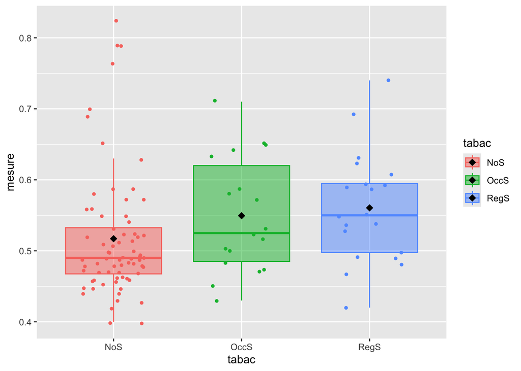

```r
library(ggplot2)
ggplot(marqueur, aes(y=mesure, x=tabac,colour=tabac ,fill=tabac))+
geom_boxplot(alpha=0.5, outlier.alpha=0)+geom_jitter(width=0.25,size=1)+
stat_summary(fun=mean, colour="black", geom="point",shape=18, size=3)
```

📈 The three boxplots suggest that there seems to be a small impact of the factor `tabac` on the variable `measure`.

## 1.1. Regular Model

| Factor I/Factor II | Modality 1 | ⋯ | Modality $K$ |
| --- | --- | --- | --- |
| Modality 1 | $Y_{i11}=\mu_{11}+\epsilon_{i11}$ | ⋯ | $Y_{i1K}=\mu_{1K}+\epsilon_{i1K}$ |
| $\vdots$ | $\vdots$ | $\vdots$ | $\vdots$ |
| Modality $J$ | $Y_{iJ1}=\mu_{J1}+\epsilon_{iJ1}$ | ⋯ | $Y_{iJK}=\mu_{JK}+\epsilon_{iJK}$ |

**[Regular Model]**
We define the **linear Gaussian regression model (ANOVA 2-factors model)** in its regular form as follows: for any $i\in\{1,\ldots,n_{jk}\}$ and any $j\in\{1,\dots,J\}:\mathcal{J}, \ k\in\{1,\dots,K\}:=\mathcal{K}$
$$\begin{equation*}
\label{eq:Anova1_RM}
\tag{Anova2 [RM]}
Y_{ijk}=\mu_{jk}+\epsilon_{ijk},\quad
\end{equation*}$$
where $\epsilon_{ijk}\stackrel{i.i.d.}{\sim}\mathcal{N}(0,\sigma^2).$

📌 **Note**:This assumption can be verified as discussed in the previous chapter.

Now, let’s express our regular ANOVA 2 model in matrix form. To do this, we will use lexicographic ordering to define:

Denote the $n_{jk}$ observations in the $(j,k)$-cell by
$$\boldsymbol{Y}_{\cdot jk}=(Y_{1jk},\cdots,
Y_{n_{jk}jk})^\top\in\mathbb{R}^{n_{jk}}$$
Denote by $\boldsymbol{\mu}$
$$\boldsymbol{\mu}=(\mu_{11},\cdots,\mu_{1K},\cdots,\mu_{JK}
)^\top\in\mathbb{R}^{JK},$$
and
$$\boldsymbol{Y}=\left(
\begin{array}{c}
\boldsymbol{Y}_{.11}\\
\vdots\\
\boldsymbol{Y}_{.1K}\\
\boldsymbol{Y}_{.21}\\
\vdots\\
\boldsymbol{Y}_{.2K}\\
\vdots\\
\boldsymbol{Y}_{.J1}\\
\vdots\\
\boldsymbol{Y}_{.JK}
\end{array}
\right)
\in\mathbb{R}^n, \quad
\boldsymbol{\epsilon}=\left(
\begin{array}{c}
\boldsymbol{\epsilon}_{.11}\\
\vdots\\
\boldsymbol{\epsilon}_{.1K}\\
\boldsymbol{\epsilon}_{.21}\\
\vdots\\
\boldsymbol{\epsilon}_{.2K}\\
\vdots\\
\boldsymbol{\epsilon}_{.J1}\\
\vdots\\
\boldsymbol{\epsilon}_{.JK}
\end{array}
\right)
\in\mathbb{R}^n,\quad C = \left(
\begin{array}{cccc}
{\Large{\mathbf{1}}}_{n_{11}} & 0 & & \\
0 &
{\Large{\mathbf{1}}}_{n_{12}} & &\vdots\\
\vdots & & \ddots &0\\
& & &
{\Large{\mathbf{1}}}_{n_{JK}}\\
\end{array}
\right)\in\mathbb{R}^{n\times JK}$$

📌 **Note**: $\text{Rank}(C)=JK$,**indicating that $C$ has full rank**. Therefore, our model can be expressed as:

**[Regular Model]**
We define the **linear Gaussian regression model (ANOVA 2-factors model)** in its regular matrix form as follows:
$$\begin{equation*}
\label{eq:ANOVA2_RM}
\tag{ANOVA 2 [RM]}
\boldsymbol{Y}=C\boldsymbol{\mu}+\boldsymbol{\epsilon},
\end{equation*}$$
where $\boldsymbol{\epsilon}\sim\mathcal{N}(\boldsymbol{0}_n,\sigma^2\mathbf{I}_n)$

## 1.2. Singular Model

Starting from the standard model expressed as $Y_{ijk} = \mu_{jk} + \epsilon_{ijk}$, we can examine the following decomposition of $\mu_{jk}$:

$$\forall\; j \in \mathcal{J}, \quad \forall\; k \in \mathcal{K}, \quad
\mu_{jk} = \mu + \alpha_j + \beta_k + \gamma_{jk}$$

Where:

- $(\alpha_j)_j$ denotes **the main effect of the first factor**.
- $(\beta_k)_k$ signifies **the main effect of the second factor**.
- $(\gamma_{jk})_{jk}$ represents **the interaction effect between the two factors**.

| Factor I/Factor II | Modality 1 | ⋯ | Modality $K$ |
| --- | --- | --- | --- |
| Modality 1 | $Y_{i11}=\mu+\alpha_1+\beta_1+\gamma_{11}+\epsilon_{i11}$ | ⋯ | $Y_{i1K}=\mu+\alpha_1+\beta_K+\gamma_{1K}+\epsilon_{i1K}$ |
| $\vdots$ | $\vdots$ | $\vdots$ | $\vdots$ |
| Modality $J$ | $Y_{iJ1}=\mu+\alpha_J+\beta_1+\gamma_{J1}+\epsilon_{iJ1}$ | ⋯ | $Y_{iJK}=\mu+\alpha_J+\beta_K+\gamma_{JK}+\epsilon_{iJK}$ |

**[Singular Model]**
We define the **linear Gaussian regression model (ANOVA 2-factors model)** in its singular form as follows for all $j\in\mathcal{J}$ and for all $k\in\mathcal{K}$
$$\begin{equation*}
\label{eq:Anova2_SM}
\tag{Anova2 [SM]}
Y_{ijk}=\mu+\alpha_j+\beta_k+\gamma_{jk}+\epsilon_{ijk}
\end{equation*}$$
where
$$\epsilon_{ijk}\stackrel{i.i.d.}{\sim}\mathcal{N}(0,\sigma^2).$$

Now, let’s express our singular ANOVA 2 model in matrix form. Define the following full rank matrices $A\in\mathbb{R}^{n\times J}$ and $B\in\mathbb{R}^{n\times K}$
$$A = \left(
\begin{array}{cccc}
{\Large{\mathbf{1}}}_{n_{1+}} & 0 & & \\
0 &
{\Large{\mathbf{1}}}_{n_{2+}} & &\vdots\\
\vdots & & \ddots &0\\
& & &
{\Large{\mathbf{1}}}_{n_{J+}}\\
\end{array}
\right)
,\quad B= \left(
\begin{array}{cccc}
{\Large{\mathbf{1}}}_{n_{11}} &0 & & \\
0& {\Large{\mathbf{1}}}_{n_{12}} & &\vdots\\
\vdots & & \ddots &0\\
& & & {\Large{\mathbf{1}}}_{n_{1K}}\\
{\Large{\mathbf{1}}}_{n_{21}} &0 & & \\
0& {\Large{\mathbf{1}}}_{n_{22}} & &\vdots\\
\vdots & & \ddots &0\\
& & & {\Large{\mathbf{1}}}_{n_{2K}}\\
{\Large{\mathbf{1}}}_{n_{J1}} &0 & & \\
0& {\Large{\mathbf{1}}}_{n_{J2}} & &\vdots\\
\vdots & & \ddots &0\\
& & & {\Large{\mathbf{1}}}_{n_{JK}}\\
\end{array}
\right)$$

Define

- $\boldsymbol{\alpha}=(\alpha_1,\cdots,\alpha_J)^\top\in\mathbb{R}^J$,
- $\boldsymbol{\beta}=(\beta_1,\cdots,\beta_K)^\top\in\mathbb{R}^K$ and
- $\boldsymbol{\gamma}=\boldsymbol{\gamma}=(\gamma_{11},\cdots,\gamma_{1K},\cdots,\gamma_{JK} )^\top\in\mathbb{R}^{JK}$.

Therefore, $\boldsymbol{\theta}$ and $\boldsymbol{X}$ are defined as

- $\boldsymbol{\theta}^\top=(\mu,\boldsymbol{\alpha}^\top,\boldsymbol{\beta}^\top,\boldsymbol{\gamma}^\top)\in\mathbb{R}^{JK+J+K+1}$
- $\boldsymbol{X}=[{\Large{\mathbf{1}}}_n \ | \ A\ | \ B\ | \ C]\in\mathbb{R}^{n\times(1+J+K+JK)}$.

📌 **Note**: $\text{Rank}(X)=JK$, indicating that it does **not** have full rank.

**[Singular Model]**
We define the **linear Gaussian regression model (ANOVA 2 factor2)** in its singular matrix form as follows:
$$\begin{equation*}
\label{eq:ANOVA2_SM}
\tag{ANOVA2 [SM]}
\boldsymbol{Y}=\mu{\Large{\mathbf{1}}}_n+A\boldsymbol{\alpha}+B\boldsymbol{\beta}+C\boldsymbol{\gamma}+\boldsymbol{\epsilon}=\boldsymbol{X}\boldsymbol{\theta}+\boldsymbol{\epsilon}
\end{equation*}$$
where $\boldsymbol{\epsilon}\sim\mathbb{N}(\boldsymbol{0}_n,\sigma^2\mathbf{I}_n)$

# 2. Estimation of the Model

**Regular Model (Full Rank Design Matrix)**

In the case where $C$ is a full rank matrix, the estimation of the model parameters is defined as:
$$\widehat{\boldsymbol{\mu}} = \underset{\boldsymbol{\mu}\in
\mathbb{R}^{JK}}{\arg \min} \|\boldsymbol{Y}- C \boldsymbol{\mu}\|^2.$$

The parameter estimates are given by
$$\widehat{\boldsymbol{\mu}} = (C^\top C)^{-1} C^\top \boldsymbol{Y},$$
which is unique due to the full rank of $C$.

**Singular Model (Not Full Rank Design Matrix)**

When the design matrix $\boldsymbol{X}$ is **not** full rank, the estimation is given by:
$$\widehat{\boldsymbol{\theta}} \in \underset{\boldsymbol{\theta}\in
\mathbb{R}^{1+J+K+JK}}{\arg \min} \|\boldsymbol{Y}-
\boldsymbol{X}\boldsymbol{\theta}\|^2.$$

The parameter estimate $\widehat{\boldsymbol{\theta}}$ is **not unique** since $\boldsymbol{X}$ is not full rank. To obtain a unique solution, constraints must be imposed:
$$(1+J+K+JK) - \text{Rank}(\boldsymbol{X}) = (1+J+K+JK) - JK = 1+J+K.$$

This constraint ensures that we can identify a specific solution among the infinite possibilities that arise due to the singularity of $\boldsymbol{X}$.

📌 **Note**: For both models, the prediction is unique and can be expressed as:

$$\widehat{\boldsymbol{Y}} = P_\boldsymbol{X}\boldsymbol{Y}=
\boldsymbol{X}\widehat{\boldsymbol{\theta}}, \quad
\widehat{\boldsymbol{Y}} = P_C \boldsymbol{Y}= C
\widehat{\boldsymbol{\mu}}.$$

## 2.1. The Classic used constraints

1.$\,$ **Regular model**. $\mu=\alpha_j=\beta_k=0$ $\forall j\in\mathcal{J}$,$\forall k\in\mathcal{K}$

**Ⓡ** `mod0<-lm(mesure~-1+alcool:tabac,data=marqueur)`

2.$\,$ **By default: `contr.treatment`** $\quad\alpha_1=\beta_1=\gamma_{j1}=\gamma_{1k}=0$, $\forall (j,k)\in\mathcal{J}\times\mathcal{K}$

**Ⓡ** `mod1<-lm(mesure~alcool*tabac, data=marqueur)` **Ⓡ** `mod1<-l lm(mesure ~ alcool * tabac, data = marqueur, contrasts = list(tabac = "contr.treatment", alcool = "contr.treatment"))`

3.$\,$ **Change reference cells $j'\neq 1$ or/and $k'\neq 1$:** $\quad\alpha_{j'}=\beta_{k'}=\gamma_{jk'}=\gamma_{j'k}=0$, $\forall (j,k)\in\mathcal{J}\times\mathcal{K}$

**Ⓡ** `marqueur$alcool = relevel(marqueur$alcool, ref="RegD")`  
`marqueur$tabac = relevel(marqueur$tabac, ref="RegS")`  
`mod2<-lm(mesure~alcool*tabac,data=marqueur)`

3.$\,$ **Contrast sum:** $\quad\sum_{j=1}^J\alpha_j=\sum_{k=1}^K\beta_k=\sum_{k=1}^K\gamma_{j'k}=\sum_{j=1}^J\gamma_{jk'}=0$, $\forall (j',k')\in\mathcal{J}\times\mathcal{K}$$

**Ⓡ** `mod3<-lm(mesure~alcool*tabac,contrasts=list(tabac="contr.sum",alcool="contr.sum"),data=marqueur)`

## 2.2. Empirical means

**Some notations** Let us define the different empirical means involved in our theoretical results.

| Empirical Mean of Observervations | General setting | Balanced plan |
| --- | --- | --- |
| admitting modality $(j,k)$ | $\overline{Y}_{\cdot jk}=\frac{1}{n_{jk}}\sum_{i=1}^{n_{jk}}Y_{ijk}$ | $\overline{Y}_{\cdot jk}=\frac{1}{I}\sum_{i=1}^{I}Y_{ijk}$ |
| admitting $j$ | $\begin{array}{ll}\overline{Y}_{\cdot j\cdot}&=\frac{1}{n_{j\cdot}}\sum_{k=1}^K\sum_{i=1}^{n_{jk}}Y_{ijk}\\ &=\frac{1}{n_{j\cdot}}\sum_{k=1}^Kn_{jk}\overline{Y}_{\cdot jk} \end{array}$ | $\begin{array}{ll}\overline{Y}_{\cdot j\cdot}&=\frac{1}{IK}\sum_{k=1}^K\sum_{i=1}^{I}Y_{ijk}\\ &=\frac{1}{K}\sum_{k=1}^K\overline{Y}_{\cdot jk} \end{array}$ |
| admitting $k$ | $\begin{array}{ll}\overline{Y}_{\cdot \cdot k}&=\frac{1}{n_{\cdot k}}\sum_{j=1}^J\sum_{i=1}^{n_{jk}}Y_{ijk}\\ &=\frac{1}{n_{\cdot k}}\sum_{j=1}^Jn_{jk}\overline{Y}_{\cdot jk} \end{array}$ | $\begin{array}{ll}\overline{Y}_{\cdot \cdot k}&=\frac{1}{IJ}\sum_{i=1}^I\sum_{j=1}^JY_{ijk}\\ &=\frac{1}{J}\sum_{j=1}^{J}\overline{Y}_{\cdot jk} \end{array}$ |

| Empirical Mean of | General setting | Balanced plan |
| --- | --- | --- |
| All observervation | $\overline{Y}_{\cdot \cdot \cdot}=\frac{1}{n} \sum_{j,k} \sum_{i=1}^{n_{jk}} Y_{ijk}$ | $\overline{Y}_{\cdot \cdot \cdot}=\frac{1}{IJK} \sum_{j,k} \sum_{i=1}^I Y_{ijk}$ |
| The Empirical mean of the $\overline{Y}_{\cdot jk}$ | $\begin{array}{ll}\overline{\overline{Y}}_{\cdot j \cdot}&=\frac{1}{K}\sum_{k} \overline{Y}_{\cdot jk}\\ &=\frac{1}{K}\sum_{k}\frac{1}{n_{jk}}\sum_{i=1}^{n_{jk}}Y_{ijk} \end{array}$ | $\begin{array}{ll}\overline{Y}_{\cdot j\cdot}&=\frac{1}{K} \sum_{k} \overline{Y}_{\cdot jk}\\ &=\frac{1}{IK}\sum_{i,k}Y_{ijk} \end{array}$ |
| The Empirical mean of the $\overline{Y}_{\cdot jk}$ | $\begin{array}{ll}\overline{\overline{Y}}_{\cdot \cdot k}&=\frac{1}{J}\sum_{j} \overline{Y}_{\cdot jk}\\ &=\frac{1}{J}\sum_{j}\frac{1}{n_{jk}}\sum_{i=1}^{n_{jk}}Y_{ijk} \end{array}$ | $\begin{array}{ll}\overline{Y}_{\cdot\cdot k}&=\frac{1}{J}\sum_{j}\overline{Y}_{\cdot jk}\\=&\frac{1}{IJ}\sum_{i,j} Y_{ijk} \end{array}$ |
| The Empirical mean of the $\overline{Y}_{\cdot jk}$ | $\begin{array}{ll}\overline{\overline{\overline{Y}}}_{\cdot \cdot \cdot}&=\frac{1}{JK}\sum_{j,k}\overline{Y}_{\cdot jk}\\ &=\frac{1}{JK}\sum_{j,k}\frac{1}{n_{jk}}\sum_{i=1}^{n_{jk}}Y_{ijk} \end{array}… | $\begin{array}{ll}\overline{Y}_{\cdot \cdot \cdot}&=\frac{1}{JK}\sum_{i=1}^I\sum_{j,k}\overline{Y}_{\cdot jk}\\ &=\frac{1}{IJK}\sum_{i,j,k}Y_{ijk} \end{array}$ |

**Ⓡ** **Example: Dataset Intima Media**

**Ⓡ** To display the empirical mean (EM) for each cell defined by the factor `alcool:tabac`:
$$\overline{Y}_{\cdot
jk}=\frac{1}{n_{jk}}\sum_{i=1}^{n_{jk}}Y_{ijk},$$
we can use the following code.

```r
moy_jk<-tapply(marqueur$mesure,list(Tabac=marqueur$tabac,Alcool=marqueur$alcool), mean)
knitr::kable(moy_jk)
```

|  | NoD | OccD | RegD |
| --- | --- | --- | --- |
| NoS | 0.4861111 | 0.5208889 | 0.5600000 |
| OccS | 0.5400000 | 0.5450000 | 0.6400000 |
| RegS | 0.5800000 | 0.5491667 | 0.5766667 |

**Ⓡ** The empirical mean of all the previous the means $\overline{Y}_{\cdot jk}$ for each cell $(j,k)$
$$\overline{\overline{\overline{Y}}}_{\cdot\cdot\cdot}=\frac{1}{JK}\sum_{j=1}^J\sum_{k=1}^K
\overline{Y}_{\cdot j k}$$
is `mean(moy_jk)`=0.5553148, while the empirical mean of all observations $Y_{ijk}$
$$\overline{Y}_{\cdot\cdot\cdot}
=\frac{1}{n}\sum_{j=1}^J\sum_{k=1}^K\sum_{i=1}^{n_{jk}} Y_{ij
k}=0.5302727$$
is different as the experimental design is unbalanced.

**Ⓡ** Note that it is also possible to display the empirical means of the empirical mean $\overline{Y}_{\cdot jk}$ admitting modality $j$
$$\overline{\overline{Y}}_{\cdot j\cdot}=\frac
1K\sum_{k=1}^K\overline{Y}_{\cdot jk}$$

```r
EM_EM_j=colMeans(moy_jk)
EM_EM_j=as.data.frame(EM_EM_j)
names(EM_EM_j)="EM of the EM per cell (j,k) having modality j"
knitr::kable(EM_EM_j)
```

|  | EM of the EM per cell (j,k) having modality j |
| --- | --- |
| NoD | 0.5353704 |
| OccD | 0.5383519 |
| RegD | 0.5922222 |

**Ⓡ** Similary, the empirical means of the empirical mean $\overline{Y}_{\cdot jk}$ admitting modality $k$
$$\overline{\overline{Y}}_{\cdot \cdot k}=\frac
1J\sum_{j=1}^J\overline{Y}_{\cdot jk}$$

```r
EM_EM_k=rowMeans(moy_jk)
EM_EM_k=as.data.frame(EM_EM_k)
names(EM_EM_k)=" EM of the EM per cell (j,k) having modality k"
knitr::kable(EM_EM_k)
```

|  | EM of the EM per cell (j,k) having modality k |
| --- | --- |
| NoS | 0.5223333 |
| OccS | 0.5750000 |
| RegS | 0.5686111 |

**Ⓡ** Display the empirical mean of the observations $Y_{\cdot ijk}$ having modality $j$
$$\overline{Y}_{\cdot j \cdot }=\frac {1}{n_{j\cdot
}}\sum_{k=1}^K\sum_{i=1}^{n_{jk}}Y_{\cdot ijk}$$

```r
EM_j=tapply(marqueur$mesure,list(Alcool=marqueur$alcool),mean)
EM_j=as.data.frame(EM_j)
names(EM_j)="EM of the observations having modality j"
knitr::kable(EM_j)
```

|  | EM of the observations having modality j |
| --- | --- |
| NoD | 0.5013043 |
| OccD | 0.5304225 |
| RegD | 0.5712500 |

**Ⓡ** Similary, display the empirical mean of the observations $Y_{\cdot ijk}$ having modality $j$
$$\overline{Y}_{\cdot \cdot k}=\frac {1}{n_{\cdot
k}}\sum_{j=1}^J\sum_{i=1}^{n_{jk}}Y_{\cdot ijk}$$

```r
EM_k=tapply(marqueur$mesure,list(Tabac=marqueur$tabac),mean,na.rm=TRUE)
EM_k=as.data.frame(EM_k)
names(EM_k)="EM of the observations having modality k"
knitr::kable(EM_k)
```

|  | EM of the observations having modality k |
| --- | --- |
| NoS | 0.5170833 |
| OccS | 0.5494444 |
| RegS | 0.5605000 |

## 2.3. Theoretical results

**[Proposition 3]**  
Consider the linear Gaussian regression model (ANOVA 2-factors model) in its singular form. For the following constraints in the balanced plan, the estimations are as follows

| Constraints/Estimators | $\widehat{\mu}$ | $\widehat{\alpha_j}$ | $\widehat{\beta_k}$ | $\widehat{\gamma_{jk}}$ |
| --- | --- | --- | --- | --- |
| $\begin{array}{ll} \forall (j,k)\\ \mu=0\\ \alpha_j=\beta_k=0 \end{array}$ | $\widehat\mu=0$ | $\widehat\alpha_j=0$ | $\widehat\beta_k=0$ | $\widehat\gamma_{jk}=\overline{Y}_{\cdot jk}$ |
| $\begin{array}{ll} \forall (j,k)\\ \alpha_1=0\\ \beta_1=0\\ \gamma_{j1}=0\\ \gamma_{1k}=0 \end{array}$ | $\widehat\mu=\overline{Y}_{\cdot 11}$ | $\widehat\alpha_j=\overline{Y}_{\cdot j1}-\overline{Y}_{\cdot 11}$ | $\widehat\beta_k=\overline{Y}_{\cdot 1 k}-\overline{Y}_{\cdot 11}$ | $\widehat\gamma_{jk}=\overline{Y}_{\cdot jk}+\overline{Y}_{\cdot 11}-\overline{Y}_{\cdot j1}-\overline{Y}_{\cdot 1k}$ |
| $\begin{array}{ll} \forall (j',k')\\ \sum_{j=1}^J\alpha_j=0\\ \sum_{k=1}^K\beta_k=0\\ \sum_{k=1}^K\gamma_{j'k}=0\\ \sum_{j=1}^J\gamma_{jk'}=0 \end{array}$ | $\widehat\mu=\overline{Y}_{\cdot\cdot\cdot}$ | $\widehat\alpha_j=\overline{Y}_{\cdot j\cdot}-\overline{Y}_{\cdot\cdot\cdot}$, $\forall j\neq J$ | $\widehat\beta_k=\overline{Y}_{\cdot \cdot k}-\overline{Y}_{\cdot\cdot\cdot}$, $\forall k\neq K$ | $\widehat\gamma_{jk}=\overline{Y}_{\cdot jk}+\overline{Y}_{\cdot\cdot\cdot}-\overline{Y}_{\cdot j \cdot}-\overline{Y}_{\cdot\cdot k}$ |

📝. **Remarks**

- **The results in the previous proposition is only true in the setting of a balanced plan!!** But it is easy to calculate it in the case of an unbalanced plan. (Let in exercise)
- **$\mu=\alpha_j=\beta_k=0$, $\forall (j,k)$** It’s correspond to the regular model.
- **$\alpha_1=\beta_1=\gamma_{j1}=\gamma_{1k}=0$, $\forall (j,k)$.** Note that $\widehat\alpha_1=\widehat\beta_1=\widehat\gamma_{1k}=\widehat\gamma_{j1}=0$,$\forall (j,k)$.
- **$\sum_{j=1}^J\alpha_j=\sum_{k=1}^K\beta_k=\sum_{k=1}^K\gamma_{j'k}=\sum_{j=1}^J\gamma_{jk'}=0$, $\forall (j',k')$.** Note that **Ⓡ** does not display $\widehat\alpha_J=-\sum_{j=1}^{J-1}\widehat\alpha_j$, $\widehat\beta_K=-\sum_{k=1}^{K-1}\widehat\beta_k$, $\widehat\gamma_{Jk}=-\sum_{j=1}^{J-1}\widehat\alpha_j$ and $\widehat\gamma_{jK}=-\sum_{k=1}^{K-1}\widehat\alpha_j$ $\forall (j,k)$. We need to compute them manually when required.

*Sketch of proof.*

- First recall that in the the regular model, the OLSE of $\mu_{jk}$ is
  $$\widehat\mu_{jk}=\overline{Y}_{\cdot jk}$$
- Then recall that the estimation of $\widehat{Y}_{ijk}$ is unique whatever the used constraints. Then by identification it comes
  $$\widehat\mu_{jk}=\overline{Y}_{\cdot
  jk}=\widehat\mu+\widehat\alpha_j+\widehat\beta_k+\widehat\gamma_{jk}$$
- We conclude by using the constraints.

**Ⓡ** **Example: Dataset Intima Media**

**Implement sum constraints**
$$\sum_{j=1}^J\alpha_j=\sum_{k=1}^K\beta_k=\sum_{j=1}^J\gamma_{jk'}=\sum_{k=1}^K\gamma_{j'k}=0,
\quad\forall j',\,k'.$$

```r
MOD<-lm(mesure~alcool*tabac,contrasts=list(tabac="contr.sum",alcool="contr.sum"),data=marqueur)
summary(MOD)
```

```
##
## Call:
## lm(formula = mesure ~ alcool * tabac, data = marqueur, contrasts = list(tabac = "contr.sum",
##     alcool = "contr.sum"))
##
## Residuals:
##      Min       1Q   Median       3Q      Max
## -0.12917 -0.05089 -0.02003  0.03389  0.29911
##
## Coefficients:
##                Estimate Std. Error t value Pr(>|t|)
## (Intercept)     0.55531    0.01450  38.296   <2e-16 ***
## alcool1        -0.01994    0.02120  -0.941   0.3491
## alcool2        -0.01696    0.01606  -1.056   0.2934
## tabac1         -0.03298    0.01616  -2.041   0.0438 *
## tabac2          0.01969    0.02426   0.812   0.4190
## alcool1:tabac1 -0.01628    0.02335  -0.697   0.4873
## alcool2:tabac1  0.01552    0.01807   0.859   0.3926
## alcool1:tabac2 -0.01506    0.03312  -0.455   0.6504
## alcool2:tabac2 -0.01304    0.02634  -0.495   0.6217
## ---
## Signif. codes:  0 '***' 0.001 '**' 0.01 '*' 0.05 '.' 0.1 ' ' 1
##
## Residual standard error: 0.08525 on 101 degrees of freedom
## Multiple R-squared:  0.1033, Adjusted R-squared:  0.03224
## F-statistic: 1.454 on 8 and 101 DF,  p-value: 0.1837
```

⚠️Recall that**Ⓡ** renames the modalities.

| Name | Outputs | Estimates | In terms of empirical means |
| --- | --- | --- | --- |
| `Intercept` | 0.5553148 | $\widehat\mu$ | $\overline{\overline{\overline{Y}}}_{\cdot\cdot\cdot}$ |
| `alcool1` | -0.0199444 | $\widehat\alpha_1$ | $\overline{\overline{Y}}_{\cdot 1\cdot}-\overline{\overline{\overline{Y}}}_{\cdot\cdot\cdot}$ |
| `alcool2` | -0.016963 | $\widehat\alpha_2$ | $\overline{\overline{Y}}_{\cdot 2\cdot}-\overline{\overline{\overline{Y}}}_{\cdot\cdot\cdot}$ |
| `tabac1` | -0.0329815 | $\widehat\beta_1$ | $\overline{\overline{Y}}_{\cdot \cdot 1}-\overline{\overline{\overline{Y}}}_{\cdot\cdot\cdot}$ |
| `tabac2` | 0.0196852 | $\widehat\beta_2$ | $\overline{\overline{Y}}_{\cdot \cdot 2}-\overline{\overline{\overline{Y}}}_{\cdot\cdot\cdot}$ |
| `alcool1:tabac1` | -0.0162778 | $\widehat\gamma_{11}$ | $\overline{Y}_{\cdot 11}+\overline{\overline{\overline{Y}}}_{\cdot\cdot\cdot}-\overline{\overline{Y}}_{\cdot 1\cdot }-\overline{\overline{Y}}_{\cdot \cdot 1}$ |
| `alcool2:tabac1` | 0.0155185 | $\widehat\gamma_{21}$ | $\overline{Y}_{\cdot 21}+\overline{\overline{\overline{Y}}}_{\cdot\cdot\cdot}-\overline{\overline{Y}}_{\cdot 2\cdot }-\overline{\overline{Y}}_{\cdot \cdot 1}$ |
| `alcool1:tabac2` | -0.0150556 | $\widehat\gamma_{12}$ | $\overline{Y}_{\cdot 12}+\overline{\overline{\overline{Y}}}_{\cdot\cdot\cdot}-\overline{\overline{Y}}_{\cdot 1\cdot }-\overline{\overline{Y}}_{\cdot \cdot 2}$ |
| `alcool2:tabac2` | -0.013037 | $\widehat\gamma_{22}$ | $\overline{Y}_{\cdot 22}+\overline{\overline{\overline{Y}}}_{\cdot\cdot\cdot}-\overline{\overline{Y}}_{\cdot 2\cdot }-\overline{\overline{Y}}_{\cdot \cdot 2}$ |

📝 With our notations and if one calculate the OLSE in the setting of unbalanced plan with the constraints sums: some coefficients have to be calculated by hand
$$\widehat\alpha_3=-(\widehat\alpha_1+\widehat\alpha_2),\qquad\widehat\beta_3=-(\widehat\beta_1+\widehat\beta_2),\qquad\widehat\gamma_{13}=(\widehat\gamma_{11}+\widehat\gamma_{12})\qquad\text{and}\qquad\widehat\gamma_{23}=-(\widehat\gamma_{21}+\widehat\gamma_{22})$$

**Unbiased estimator of $\sigma^2$**

**[Proposition 4]**
Consider the linear Gaussian regression model (ANOVA 2-factors model) in its singular form under the posutlats **[P1]–[P3]**. For any classical constraint, an unbiased estimator of $\sigma^2$ is
$$\widehat\sigma^2=\frac{\|\boldsymbol{Y}-\widehat{\boldsymbol{Y}}\|^2}{n-JK}=\frac{1}{n-JK}\sum_{j=1}^J\sum_{k=1}^K\sum_{i=1}^{n_{jk}}(Y_{ijk}-
\overline{Y}_{\cdot jk})^2,$$
where $\widehat{\boldsymbol{Y}}=P_\boldsymbol{X}\boldsymbol{Y}=P_C\boldsymbol{Y}$

Moreover, under the gaussian assumption **[P4]**
$$\frac{(n-JK)\widehat\sigma^2}{\sigma^2}\sim\chi^2(n-JK).$$

*Proof.* Immediate according to previous Chapters.$\square$

📌 **Note**: Whether we consider the regular or the singular model, we have the equality of ranks:
$$\text{Rank}(C) = \text{Rank}(\boldsymbol{X}) = JK.$$

# 3. Tests

Let us define the different following models:

- $\mathcal{M}_{\mu}\,:\, Y=\mu{\Large{\mathbf{1}}}_n+\boldsymbol{\epsilon}$
- $\mathcal{M}_{\mu,\alpha}\,:\, Y=\mu{\Large{\mathbf{1}}}_n+A\boldsymbol{\alpha}+\boldsymbol{\epsilon}$
- $\mathcal{M}_{\mu,\beta}\,:\, Y=\mu{\Large{\mathbf{1}}}_n+B\boldsymbol{\beta}+\boldsymbol{\epsilon}$
- $\mathcal{M}_{\mu,\alpha,\beta}\,:\, Y=\mu{\Large{\mathbf{1}}}_n+A\boldsymbol{\alpha}+B\boldsymbol{\beta}+\boldsymbol{\epsilon}$
- $\mathcal{M}_{\mu,\alpha,\beta,\gamma}\,:\, Y=\mu{\Large{\mathbf{1}}}_n+A\boldsymbol{\alpha}+B\boldsymbol{\beta}+C\boldsymbol{\gamma}+\boldsymbol{\epsilon}$

where $\boldsymbol{\epsilon}\sim\mathcal{N}(0_n,\sigma^2\mathbf{I}_n)$. Tests can be performed using different methods. **Ⓡ** offers two types of analyses.

## 3.1. Type I Analysis

**Type I Analysis.** This can be executed using the command `anova(mod_full)`, where `mod_full` represents the model $\mathcal{M}_{\mu,\alpha,\beta,\gamma}$. The line-by-line tests conducted in the `anova` analysis are
$$R_j^a =\{F_{j}^a>q^{ {\Large{\mathcal{F}}}_{d_j,n-JK}
}_{1-\alpha}\},\quad \text{for}\quad j=1,\ldots,3$$

and are summarized in the following table:

| `anova` | Tests | `F Value` | Fisher law |
| --- | --- | --- | --- |
| **Line 1.** | $\mathcal{H}_0 : \mathcal{M}_{\mu} \,\,\,\,\,\,\,\, vs \,\, \mathcal{H}_1 : \mathcal{M}_{\mu,\alpha}$ | $F_{1}^a=\\|P_{1_n}Y-P_{[{\Large{\mathbf{1}}}_n \ A]}Y\\|^2/((J-1)\widehat\sigma^2)$ | ${\Large{\mathcal{F}}}_{J-1,n-JK}$ |
| **Line 2.** | $\mathcal{H}_0 : \mathcal{M}_{\mu,\alpha} \,\,\,\, vs \,\, \mathcal{H}_1 : \mathcal{M}_{\mu,\alpha,\beta}$ | $F_{2}^a=\\|P_{[{\Large{\mathbf{1}}}_n \ A]}Y-P_{[{\Large{\mathbf{1}}}_n \ A \ B]}Y\\|^2/((K-1)\widehat{\sigma}^2)$ | ${\Large{\mathcal{F}}}_{K-1,n-JK}$ |
| **Line 3.** | $\mathcal{H}_0 : \mathcal{M}_{\mu,\alpha,\beta} \,\, vs \,\, \mathcal{H}_1 : \mathcal{M}_{\mu,\alpha,\beta,\gamma}$ | $F_{3}^a=\\|P_{[{\Large{\mathbf{1}}}_n \ A \ B]}Y-P_{X}Y\\|^2/((J-1)(K-1)\widehat\sigma^2)$ | ${\Large{\mathcal{F}}}_{(J-1)(K-1),n-JK}$ |

📌 **Note**: The Type I analysis compares nested models by introducing one by one the factors.

📌 **Note**: $\widehat\sigma^2$ is calculated from the full model $\mathcal{M}_{\mu,\alpha,\beta,\gamma}$, $s.t.$
$$\widehat\sigma^2=\frac{\|\boldsymbol{Y}-P_{[{\Large{\mathbf{1}}}_n \ A \ B \ C]}\boldsymbol{Y}\|^2}{n-JK}=\frac{\|\boldsymbol{Y}-P_{\boldsymbol{X}}\boldsymbol{Y}\|^2}{n-JK}$$

*Sketch of proof.*

First note that:

$\begin{array}{ll} &\text{Rank}(\boldsymbol{X})= \text{Rank}([{\Large{\mathbf{1}}}_n \ A \ B \ C])=JK\\ &\text{Rank}({\Large{\mathbf{1}}}_n)=1\\ &\text{Rank}([1_n \ A])=J\\ &\text{Rank}([{\Large{\mathbf{1}}}_n \ B])=K\\ &\text{Rank}([{\Large{\mathbf{1}}}_n \ A \ B])=J+K-1 \end{array}$

Moreover,

$\begin{array}{ll} &\text{Rank}(\boldsymbol{X})-\text{Rank}([{\Large{\mathbf{1}}}_n \ A \ B])=JK-(J+K-1)=(J-1)(K-1)\\ &\text{Rank}([{\Large{\mathbf{1}}}_n \ A \ B)-\text{Rank}( [{\Large{\mathbf{1}}}_n \ A])=(J+K-1)-J=K-1\\ &\text{Rank}([{\Large{\mathbf{1}}}_n \ A \ B])-\text{Rank}([1_n \ A])=(J+K-1)-J=K-1\\ &\text{Rank}([{\Large{\mathbf{1}}}_n \ A])-\text{Rank}({\Large{\mathbf{1}}}_n)=J-1 \end{array}$

Recall that by proposition 4
$$\frac{(n-JK)\widehat\sigma^2}{\sigma^2}\sim\chi^2(n-JK).$$

Then, we conclude by the *Nested* theorem of the chapter 2.$\square$

**Ⓡ** **Example: Dataset Intima Media**

```r
mod_full<-lm(mesure~alcool*tabac, data=marqueur)
anova(mod_full)
```

|  | Df | Sum Sq | Mean Sq | F value | Pr(>F) |
| --- | --- | --- | --- | --- | --- |
| alcool | 2 | 0.04616862 | 0.023084312 | 3.1765936 | 0.04592771 |
| tabac | 2 | 0.02655231 | 0.013276153 | 1.8269091 | 0.16618734 |
| alcool:tabac | 4 | 0.01180367 | 0.002950916 | 0.4060707 | 0.80389267 |
| Residuals | 101 | 0.73396722 | 0.007267002 | NA | NA |

📈 **Interpretation**

- The factor `alcool` is statistically significant (`Pr(>F)`<5%). This means there is a significant difference in the dependent variable based on the levels of `alcool` consumption. The factor `tabac` is not statistically significant (`Pr(>F)`>5%). This suggests there is no significant difference in the dependent variable based on tobacco consumption.
- The interaction between the 2 factors is also not significant (`Pr(>F)`>5%). This indicates that the effect of `alcool` on the dependent variable does not depend on the levels of `tabac` consumption, and vice versa.

**In summary**, `alcool` has a significant effect, but neither `tabac` nor the interaction have a significant impact on the dependent variable.

```r
mod_full_2<-lm(mesure~tabac*alcool, data=marqueur)
anova(mod_full_2)
```

|  | Df | Sum Sq | Mean Sq | F value | Pr(>F) |
| --- | --- | --- | --- | --- | --- |
| tabac | 2 | 0.03741487 | 0.018707437 | 2.5742991 | 0.08120057 |
| alcool | 2 | 0.03530606 | 0.017653028 | 2.4292036 | 0.09323928 |
| tabac:alcool | 4 | 0.01180367 | 0.002950916 | 0.4060707 | 0.80389267 |
| Residuals | 101 | 0.73396722 | 0.007267002 | NA | NA |

📈 The results differ from the previous model due to the **order of factors**. In the first model, `alcool` was introduced first, while in this model, `tabac` is first. In Type I analysis, the order of factors affects the results because the effects are tested sequentially, attributing variance to factors based on their entry into the model. Hence, `alcool` was significant when added first but loses significance when `tabac`is first.

## 3.2. Type II Analysis

**Type II Analysis.** This is carried out using the `Anova(mod_full)` function from the `car` package. The line-by-line tests conducted in the `Anova` analysis are
$$R_j^A =\{F_{j}^A>q^{ {\Large{\mathcal{F}}}_{d_j,n-JK}
}_{1-\alpha}\},\quad \text{for}\quad j=1,\ldots,3$$

and are summarized in the following table:

| `Anova` | Tests | `F Value` | Fisher law |
| --- | --- | --- | --- |
| **Line 1.** | $\mathcal{H}_0 : \mathcal{M}_{\mu,\beta} \,\,\,\,\, vs \,\, \mathcal{H}_1 : \mathcal{M}_{\mu,\alpha,\beta}$ | $F_{1}^A=\\|P_{[{\Large{\mathbf{1}}}_n \ B]}Y-P_{[{\Large{\mathbf{1}}}_n \ \| \ A \ \| \ B]}Y\\|^2/((J-1)\widehat\sigma^2)$ | ${\Large{\mathcal{F}}}_{J-1,n-JK}$ |
| **Line 2.** | $\mathcal{H}_0 : \mathcal{M}_{\mu,\alpha} \,\,\,\, vs \,\, \mathcal{H}_1 : \mathcal{M}_{\mu,\alpha,\beta}$ | $F_{2}^A=\\|P_{[{\Large{\mathbf{1}}}_n \ A]}Y-P_{[{\Large{\mathbf{1}}}_n \ A \ B]}Y\\|^2/((K-1)\widehat{\sigma}^2)$ | ${\Large{\mathcal{F}}}_{K-1,n-JK}$ |
| **Line 3.** | $\mathcal{H}_0 : \mathcal{M}_{\mu,\alpha,\beta} \,\, vs \,\, \mathcal{H}_1 : \mathcal{M}_{\mu,\alpha,\beta,\gamma}$ | $F_{3}^A=\\|P_{[{\Large{\mathbf{1}}}_n \ A \ B]}Y-P_{X}Y\\|^2/((J-1)(K-1)\widehat\sigma^2)$ | ${\Large{\mathcal{F}}}_{(J-1)(K-1),n-JK}$ |

📌 **Note**: The Type II analysis compares nested models by removing one of the two factors in the models without interaction (the 2 first tests).

📌 **Note**: Here again, $\widehat\sigma^2$ is calculated from the full model $\mathcal{M}_{\mu,\alpha,\beta,\gamma}$.

📝 **Remark** that $F_j^a=F_j^A$ for $j=2,3$.

**Ⓡ** **Example: Dataset Intima Media**

```r
library(car)
Anova(mod_full)
```

|  | Sum Sq | Df | F value | Pr(>F) |
| --- | --- | --- | --- | --- |
| alcool | 0.03530606 | 2 | 2.4292036 | 0.09323928 |
| tabac | 0.02655231 | 2 | 1.8269091 | 0.16618734 |
| alcool:tabac | 0.01180367 | 4 | 0.4060707 | 0.80389267 |
| Residuals | 0.73396722 | 101 | NA | NA |